# Disaggregating Time-Series with Many Indicators: An Overview of the DisaggregateTS Package

### 4.2 High-dimensional setting

We now repeat the simulation experiment in a high-dimensional setting, where the number of temporal observations is lower than the number of exogenous variables. In this case, standard methods like Chow-Lin cannot be applied. To do so, we simulate the dependent variable $Y\in \mathbb{R}^{17}$ as before, but now the set of high-frequency exogenous variables is of dimension $X \in \mathbb{R}^{68\times 100}$. Similarly, as before, we can use the following command:

```r
# Generate low-frequency yearly series and its high-frequency quarterly counterpart
set.seed(27)
n_l <- 17 # The number of low-frequency data points
n <- 68 # The number of high-frequency data points - quarterly
p_sim <- 100 # The number of the high-frequency exogenous variables.
rho_sim <- 0.8 # autocorrelation parameter
Sim_data <- TempDisaggDGP(n_l,
                          n,
                          aggRatio = 4,
                          p = p_sim,
                          rho = rho_sim)
Y_sim <- matrix(Sim_data$Y_Gen) #Extract the simulated dependent
# (low-frequency) variable
X_sim <- Sim_data$X_Gen #Extract the simulated exogenous variables - high-frequency
```

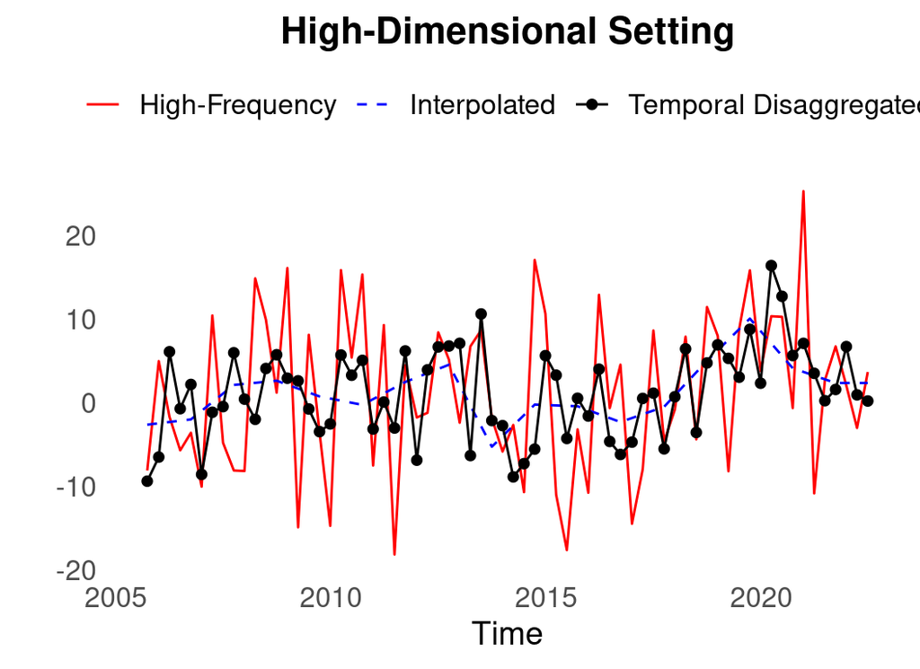

Figure 4: Temporal disaggregated and interpolated observations for the estimation under the high-dimensional setting. The plot is built using the snippet code provided in this subsection. As we used the setting `aggMat = sum`, the sum of every four disaggregated observations corresponds to an actual low-frequency observation.

As we can see from both Figures 3 and 4, the standard interpolation cannot reproduce the fluctuations of the data, making the result overly smooth. On the other hand, the temporal disaggregation methods demonstrate fluctuations in line with the actual observations. We remark that the degree of success in recovering the short-term fluctuations depends considerably on the setting, and as one may expect, performance is not as strong in the high-dimensional scenario where the estimator must simultaneously search for appropriate indicators and estimate the parameters.

We would in general caution against throwing sets of non-curated (i.e. possibly irrelevant) indicators into any of the Chow-Lin methods. Instead, we recommend that where possible, indicators that are designed to track the outcome of interest are used, e.g., we may wish to benchmark (align) monthly flash-indicators of GDP against more reliable yearly/quarterly observations, in this case, the flash estimates can be used as an indicator within a standard Chow-Lin approach. If there is a larger set of indicators which practitioners find hard to decide amongst, that is all indicators could be feasible from the practitioner view, then we recommend users may try the model-selection based `"spTD"`, and `"adaptive-spTD"` routines. In some settings, use of the classical Chow-Lin procedure becomes impossible due to the lack of low-frequency responses, in such settings it is necessary to either apply regularization or perform model-selection.

To conclude the simulation exercise, we present a set of statistics from 1,000 simulations for both the linearly interpolated and temporally disaggregated time series across the two simulation settings. The results are summarized in Table 1. As it can be observed, the temporally disaggregated time series provides a much better representation of the real data’s level of dispersion, while interpolation consistently underestimates it. In terms of MSE and MAE, the findings are mixed: for the classic case, temporal disaggregation shows lower values for both metrics, whereas in the high-dimensional setting, the opposite trend is observed.

Table 1: Mean and standard deviation (in parentheses) of key statistical measures for the high-frequency simulated observations, temporal disaggregated observations, and interpolated observations across 1000 Monte Carlo simulations. MAE and MSE are computed with respect to the high-frequency simulated observations.

Statistic

Classical_Obs

Classical_Temporal_Disaggregation

Classical_Interpolation

HighDim_Obs

HighDim_Temporal_Disaggregation

HighDim_Interpolation

Standard Deviation

2.716 (0.258)

2.888 (0.597)

1.488 (0.321)

10.089 (0.888)

8.478 (1.696)

4.18 (0.817)

Kurtosis

2.897 (0.519)

2.902 (0.527)

2.689 (0.694)

2.898 (0.558)

2.890 (0.523)

2.892 (0.772)

MSE

- (-)

2.405 (1.733)

5.158 (0.977)

- (-)

104.463 (28.519)

86.095 (16.258)

MAE

- (-)

1.185 (0.386)

1.809 (0.178)

- (-)

8.136 (1.101)

7.403 (0.735)

## 5 Empirical application

In this Section, we show how temporal disaggregation can be used in a real-world problem.

The urgent need to address climate change has propelled the scientific community to explore innovative approaches to quantify and manage greenhouse gas (GHG) emissions. Carbon intensity, a crucial metric that measures the amount of carbon dioxide equivalent emitted per unit of economic activity (e.g. sales), plays a pivotal role in assessing the environmental sustainability of industries, countries, and global economies. By focusing on emissions per unit of economic output, carbon intensity accounts for the fact that larger organizations or economies may naturally produce more emissions simply due to scale. This allows for a fair comparison of sustainability performance across different entities, regardless of size. Accurate and timely carbon accounting and the development of robust measurement frameworks are essential for effective emission reduction strategies and the pursuit of sustainable development goals. While carbon accounting frameworks offer valuable insights into emissions quantification, they are not without limitations. One of those limitations is the frequency with which this information is released, generally at an annual frequency, while most companies’ economic indicators are made public on a quarterly basis. This is a perfect example in which temporal disaggregation can be used to bridge the gap between data availability and prompt economic and financial analyses. In this application, the variable of interest is the GHG emissions for IBM between Q3 2005 and Q3 2021, at annual frequency, resulting in 17 datapoints, i.e. $Y\in \mathbb{R}^{17}$. For the high-frequency data, we used the balance sheet, income statement, and cash flow statement quarterly data between Q3 2005 and Q3 2021, resulting in 68 datapoints for the 128 variables. We remove variables that have a pairwise correlation higher than 0.99, resulting in a filtered dataset with 112 variables, i.e. $X \in \mathbb{R}^{68\times 112}$. In this example, we employed the adaptive LASSO method (`method = "adaptive-spTD"`) as a way to select the best variables that can be used to recover the high-frequency observations and we applied the `aggMat = "sum"` aggregation method. The rationale for using this method, in conjunction with `aggRatio = 4` is to ensure that the disaggregated quarterly carbon intensity values are consistent with the overall annual figures as the goal is to break down the emissions and sales data such that the sum of the quarterly carbon intensities equals the yearly total. The adaptive LASSO procedure select only seven non-zero coefficients, which are Actual sales per employee, trailing 12-month net sales, Enterprise value, Current liabilities, total liabilities and equity, total line of credit and net debt. Actual sales per employee, trailing 12-month net sales and Enterprise value indicate company sales and size, both linked to the company’s economic activity, operational intensity, and commitment to sustainability, and hence potential emissions. Current liabilities and total liabilities and equity reflect the company’s financial position and operational scale, both of which might influence emissions. Total line of credit and net debt highlight the company’s ability to borrow, which could impact investment in emissions-reducing projects. We show the results in Figure 5 alongside a linear interpolation method.

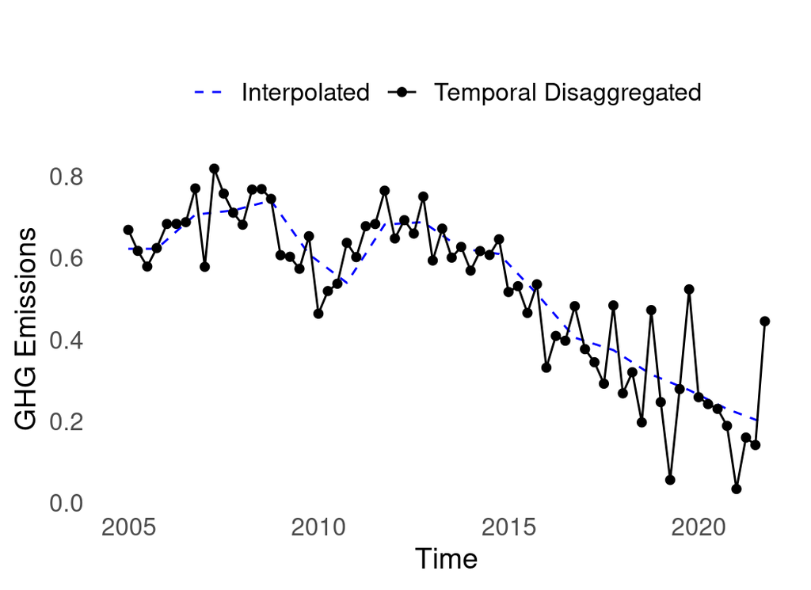

Figure 5: Temporal disaggregated and interpolated GHG emissions observations. In this example, we used the setting `aggMat = sum`, so the sum of the quarterly disaggregated GHG sums to the actual annual observation.

As it is possible to observe from the plot, the interpolated data do not fluctuate as we would expect from real GHG emissions, as the method is not conditional on the variability of the high-frequency variables. In this respect, the temporal disaggregated observations show more realistic dynamics. This result can then be used to compute the GHG intensity, computing the ratio between GHG emissions and the sales for the corresponding quarter.

## 6 Summary

In this paper, we have given an overview of the key functionality for the DisaggregateTS R package. The package builds on features of the existing tempdisagg package allowing the user to easily apply the regularized Chow-Lin type procedure of Mosley et al. (2022) and compare this with classical methods based on interpolation via smoothing (e.g. Denton 1971), or the Fernández (1981) and Fernández (1981) methods in the case where series are not co-integrated. The package may be extended in future to allow cross-sectional constraints, the disaggregation of panel time-series data, and the accommodation of factor (latent-variable) structures in the temporal-disaggregation problem.

It is important to point out that when performing disaggregation, one should be careful to select an appropriate set of indicator time-series, and not purely rely on the model-selection procedures deployed here. Whilst these methods can help pick from a set of indicators, there is still room for them to pick irrelevant/spurious series, especially given the short nature of the aggregate series. To this end, we do not recommend just relying on one method alone, but rather a user deploy several methods of disaggregation. The user should then attempt to obtain some form of (potentially qualitative) external validation of the resultant series in their application of choice. One should always remember, that as the high-frequency series is not observed, there can be no direct empirical validation of the methods other than at the aggregate scale.

### 6.1 Supplementary materials

Supplementary materials are available in addition to this article. It can be downloaded at RJ-2024-035.zip

### 6.2 CRAN packages used

DisaggregateTS, tempdisagg

### 6.3 CRAN Task Views implied by cited packages

TimeSeries

A. Belloni and V. Chernozhukov. Least squares after model selection in high-dimensional sparse models. *Bernoulli*, 19(2): 521–547, 2013.

J. Bournay and G. Laroque. Réflexions sur la méthode d’elaboration des comptes trimestriels. In *Annales de l’INSEE*, pages. 3–30 1979. JSTOR.

P.-A. Cholette. Adjusting sub-annual series to yearly benchmarks. *Survey Methodology*, 10(1): 35–49, 1984.

G. C. Chow and A. Lin. Best linear unbiased interpolation, distribution, and extrapolation of time series by related series. *The review of Economics and Statistics*, 53(4): 372–375, 1971.

G. C. Chow and A.-L. Lin. Best linear unbiased estimation of missing observations in an economic time series. *Journal of the American Statistical Association*, 71(355): 719–721, 1976.

A. Cottrell and R. Lucchetti. *Gretl User’s Guide: Gnu Regression, Econometrics and Time-series Library.* 2023. URL https://gretl.sourceforge.net/gretl-help/gretl-guide.pdf. Accessed: 2023-10-08.

E. B. Dagum and P. A. Cholette. *Benchmarking, temporal distribution, and reconciliation methods for time series.* Springer, 2006.

F. T. Denton. Adjustment of monthly or quarterly series to annual totals: An approach based on quadratic minimization. *Journal of the american statistical association*, 66(333): 99–102, 1971.

B. Efron, T. Hastie, I. Johnstone and R. Tibshirani. Least angle regression. *The Annals of Statistics*, 32(2): 407–451, 2004.

R. B. Fernández. A methodological note on the estimation of time series. *The Review of Economics and Statistics*, 63(3): 471–476, 1981.

P. Fuleky. *Macroeconomic forecasting in the era of big data: Theory and practice.* Springer, 2019.

R. B. Litterman. A random walk, markov model for the distribution of time series. *Journal of Business & Economic Statistics*, 1(2): 169–173, 1983.

L. Mosley, I. A. Eckley and A. Gibberd. Sparse Temporal Disaggregation. *Journal of the Royal Statistical Society Series A: Statistics in Society*, 185(4): 2203–2233, 2022. URL https://doi.org/10.1111/rssa.12952.

L. Mosley and K. S. Nobari. *DisaggregateTS: High-dimensional temporal disaggregation.* 2024. URL https://CRAN.R-project.org/package=DisaggregateTS. R package version 3.0.1.

E. M. Quilis. Temporal disaggregation of economic time series: The view from the trenches. *Statistica Neerlandica*, 72(4): 447–470, 2018.

C. Sax and P. Steiner. Temporal disaggregation of time series. *The R Journal*, 5(2): 80–87, 2013.

C. Sax, P. Steiner and T. Di Fonzo. *“Tempdisagg”: Methods for temporal disaggregation and interpolation of time series.* 2023. URL https://CRAN.R-project.org/package=tempdisagg. R package version 1.1.1.

G. Schwarz. Estimating the dimension of a model. *The Annals of Statistics*, 6(2): 461–464, 1978.

R. Tibshirani. Regression shrinkage and selection via the lasso. *Journal of the Royal Statistical Society: Series B (Methodological)*, 58(1): 267–288, 1996.

S. Van de Geer, P. Bühlmann and S. Zhou. The adaptive and the thresholded lasso for potentially misspecified models (and a lower bound for the lasso). *Electronic Journal of Statistics*, 5: 688–749, 2011.

M. J. Wainwright. *High-dimensional statistics: A non-asymptotic viewpoint.* Cambridge university press, 2019.

H. Zou. The adaptive lasso and its oracle properties. *Journal of the American statistical association*, 101(476): 1418–1429, 2006.

[^1]: See Dagum and Cholette (2006) for an overview of benchmarking, interpolation, temporal distribution and calendarization techniques.
[^2]: For alternative aggregations see Quilis (2018) and Sax et al. (2023). For instance, if quarterly values correspond to averages of monthly values, then the vector in equation (2) assumes the form $(0.33,0.33,0.33)$.
[^3]: noting the LARS algorithm produces solutions evaluated at a series of $\{\lambda_l\}_{l=1}^k$ points.